# Inference for the Youden curve of a multiply imputed biomarker: a band, a set of near-optimal cutoffs, and a corrected index

Author

TO CONFIRM: the author line; tools/authors.R sets it before the final render

Published

October 29, 2026

**Draft.** This rendering is a draft: its numbers come from the run labeled below and will be replaced by the production run; highlighted numbers and markers are apparatus and are stripped in final mode.

- Run: **quick**, 100 replicates per cell over 44 cells, 2026-10-29 16:46:11; Simulation study, analysis/01_simulation.R.
- Markers: 7 to confirm, 10 claims without a usable source, 0 unfilled slots (listed at the end).

**Status** (the drafting log’s opening line):

Paper test: yes on all seven questions for a constructive method paper (the Youden curve, its maximizer, and its maximum as functionals; a bootstrap-then-impute band, a comparison-based near-optimal set, and a matched optimism correction, shown by a 44-cell simulation and the NHANES application), with two plain noes: no closed form for the optimism of the step curve beyond its order (a sketch gives $n^{-2/3}$), and no formula for the band’s undercoverage under predictive mean matching, which the simulation traces to bias of the imputed curve; the first draft rests on the quick run (100 replicates per cell), six sources are missing from Zotero, and the discrete-covariate aim enters through the application and the supplement only.

The seven paper-test answers are in the drafting log.

# Abstract

Studies that impute a missing biomarker report the threshold where the averaged Youden curve peaks, without uncertainty, overstating its accuracy. We propose a band for the pooled curve by bootstrap-then-impute, a set of thresholds no other threshold beats beyond their difference’s uncertainty, and a bootstrap correction of the index. In simulation, the band covered the curve in 0.88 to 0.97 (MCSE at most 0.032) of replicates with normal imputation, but in 0.57 to 0.93 (MCSE at most 0.050) with predictive mean matching at 60% missing, where imputations were biased. The set held the best threshold in 0.93 to 1.00 (MCSE at most 0.026) at 0.33 to 0.72 of a band-based set’s length. Without missing data the index exceeded the chosen threshold’s accuracy by 0.013 to 0.043 (MCSE at most 0.005); the correction left 0.001 to 0.013 (MCSE at most 0.006). In NHANES, the cotinine set, 3.43 to 11.95 ng/mL, held the published 3.63 ng/mL cutoff.

*Keywords:* multiple imputation; Youden index; optimal cutoff; simultaneous confidence band; multiple comparisons with the best; bootstrap

# 1 Introduction

A threshold on a biomarker decides who is counted as having a condition: a threshold on serum cotinine, a metabolite of nicotine, separates people who smoke cigarettes from people who do not, and its value has been estimated from national survey data<sup>1,2</sup>. One criterion for the best threshold maximizes the sum of sensitivity and specificity, and that sum minus one is the Youden index<sup>3</sup>. When the biomarker is missing for some participants, multiple imputation, one of the most popular approaches to missing data<sup>4</sup>, fills in the missing values several times and analyses each completed dataset. In the paper that proposed nonparametric multiple imputation for ROC analysis, depression screening scores missing for part of a cohort of pregnant women were multiply imputed, the true and false positive rates were averaged across the completed datasets at each threshold, and one score was reported as “the unanimous optimum threshold”, with no statement of its uncertainty<sup>5</sup>. Applied studies impute a marker and then report an optimal cutoff<sup>6–8</sup>, and the two whose full text was read do not say how the completed datasets were combined<sup>6,7</sup>; many studies do not report the precision of their cutpoints at all<sup>9</sup>.

The reported index overstates the accuracy of the threshold it picks, because the threshold is chosen where the estimated curve happens to be high. With $F_0$ and $F_1$ the distribution functions of the marker among people without and with the condition, and a person called positive when the marker exceeds $c$, the Youden curve, its best threshold, and its maximum are
$$\begin{aligned}
J(c) &= F_0(c) - F_1(c), \\
c^* &= \arg\max_c J(c), \\
J^* &= J(c^*).
\end{aligned}$$
From $L$ completed datasets the analyst averages the empirical curves $\hat J_1, \dots, \hat J_L$ into $\bar J$, takes the threshold $\hat c$ at which $\bar J$ peaks, and reports the peak, $\max_c \bar J(c)$. Because $\max_c \bar J(c) \ge \bar J(c^*)$ in every dataset and $J(\hat c) \le J^*$, the reported index exceeds the true accuracy of the chosen threshold on average whenever the averaged curve is unbiased at $c^*$:
$$\mathrm{E}\{\max_c \bar J(c)\} - \mathrm{E}\{J(\hat c)\} \;\ge\; \mathrm{E}\{\bar J(c^*)\} - J^* \;=\; 0 .$$
Without missing data the empirical index has the largest upward bias of the usual estimators<sup>10</sup>, intervals exist for the index and the threshold<sup>11</sup>, and confidence regions exist for the sensitivity and specificity at the estimated threshold<sup>12</sup>. The empirical threshold converges at the cube-root rate to a non-normal limit CITE: the cube-root rate and the non-normal limit of an argmax of a step criterion (Kim and Pollard 1990; no readable text in Zotero)<sup>13</sup>, as does a weighted Youden threshold<sup>14</sup>. Rubin’s rules assume approximately normal estimates<sup>15</sup>, so they do not apply to the threshold, and the standard bootstrap is inconsistent for it<sup>13</sup>. When the disease status rather than the marker is missing, the ROC curve<sup>16</sup> and intervals for the Youden index<sup>17,18</sup> have been derived. When the marker is missing, imputation methods give the ROC curve and its area<sup>5,19,20</sup>. No method gives a band for the Youden curve, a set of thresholds that the data cannot separate from the best one, or a correction of the reported index from multiply imputed data.

This paper proposes all three and asks whether each works. The band estimates the covariance of the averaged curve by bootstrapping the data and imputing each resample<sup>4</sup>, and takes a sup-t critical value<sup>21</sup>. The near-optimal set keeps every threshold that no other threshold beats by more than the uncertainty of their difference, in the manner of multiple comparisons with the best<sup>22</sup> CITE: multiple comparisons with the best (Hsu 1984; no PDF in Zotero). The correction subtracts a bootstrap estimate of the optimism CITE: the bootstrap estimate of optimism (Efron 1983; Harrell, Lee, and Mark 1996; no readable text in Zotero), with each resample imputed as many times as the analysis. A simulation study then asks four questions. Does the band cover the whole curve at the nominal rate, under predictive mean matching as well as under a correctly specified imputation model? Does the set contain the best threshold at least as often as its level promises, and how much narrower is it than the set the band itself gives? Does the correction remove the optimism of the reported index? And, as a note on the order of operations, how far apart are the index from averaging the curves first and the index from maximizing in each completed dataset first? An application to serum cotinine and smoking in the National Health and Nutrition Examination Survey CITE: the NHANES 2013 to 2018 data files (no item in Zotero) then asks whether the data can choose between a published cutoff and the cohort’s own.

# 2 Methods

## 2.1 The estimand

The question a threshold answers is how accurate it is, and the question a study answers is which threshold is most accurate. We therefore take as estimand the whole Youden curve and its peak, not one threshold. With $F_d$ the distribution function of the marker $X$ in group $D = d$, and a person called positive when $X > c$, the curve, its best threshold, and its maximum are
$$\begin{aligned}
J(c) &= F_0(c) - F_1(c), \\
c^* &= \arg\max_c J(c), \\
J^* &= J(c^*).
\end{aligned}$$
A study that picks a threshold $\hat c$ from data delivers the accuracy $J(\hat c)$, which falls short of $J^*$ by the regret $J^* - J(\hat c)$. The marker is missing for some participants, at random given the disease status and observed covariates, and the disease status is always observed.

## 2.2 The pooled curve and its index

The analysis completes the data $L$ times and averages the empirical curves of the completed datasets. With $X_i^{(l)}$ the marker of participant $i$ in completed dataset $l$, observed or imputed, and $n_d$ the size of group $d$,
$$\begin{aligned}
\hat F_{dl}(c) &= n_d^{-1} \textstyle\sum_{i : D_i = d} 1\{X_i^{(l)} \le c\}, \\
\hat J_l(c) &= \hat F_{0l}(c) - \hat F_{1l}(c), \\
\bar J(c) &= L^{-1} \textstyle\sum_{l=1}^{L} \hat J_l(c).
\end{aligned}$$
The pooled curve $\bar J$ is a step function. The reported index is its maximum, $\max_c \bar J(c)$, and the chosen threshold $\hat c$ is the midpoint of the interval on which the maximum is reached, or the mean of those midpoints when several intervals tie. This is the procedure of Long, Zhang, and Hsu<sup>5</sup>, who averaged the curves of the completed datasets. The alternative, maximizing in each completed dataset first, reports the mean of the per-dataset maxima and the mean $\tilde c = L^{-1} \sum_l \hat c_l$ of the per-dataset cutoffs.

At a fixed threshold the pooled curve is an average of differences of two proportions, so it is a regular estimate, and Rubin’s rules apply to it under proper imputation<sup>15</sup>. Its maximum is not regular. The reported index exceeds the accuracy the chosen threshold delivers, in expectation, whenever the pooled curve is unbiased at $c^*$; the argument takes two lines (Supplementary note, S1.1). For the empirical curve the excess is of order $n^{-2/3}$, because the empirical threshold converges at the cube-root rate CITE: the cube-root rate of an argmax of a step criterion (Kim and Pollard 1990; no readable text in Zotero)<sup>13</sup> (S1.2). Maximizing first adds to that excess a gap that is never negative and is close to $\kappa \hat B_c / 2$, with $\kappa = -J''(c^*)$ the curvature at the peak and $\hat B_c$ the variance of the per-dataset cutoffs (S1.3).

## 2.3 A band for the curve

A band that contains the whole curve with probability 95% brackets the accuracy of every threshold at once. We estimate the covariance of the pooled curve on a grid by bootstrapping the data and imputing each resample, whose variance estimates hold when the imputation and analysis models are uncongenial<sup>4</sup>, and we impute each resample only $M$ times, which is enough when the variance is split into its parts<sup>23</sup>. The grid holds $K = 41$ equally spaced thresholds $c_1 < \dots < c_K$ between the 10% and 90% quantiles of all completed values. In each of $R_B = 1,000$ resamples, drawn with replacement within each disease group, the resample is imputed $M = 2$ times, giving curves $\hat J_{b1}, \dots, \hat J_{bM}$ on the grid with mean $\bar J_b$. Then
$$\begin{aligned}
V &= \widehat{\mathrm{Cov}}_b(\bar J_b), \\
W &= R_B^{-1} \textstyle\sum_b (M - 1)^{-1} \sum_m (\hat J_{bm} - \bar J_b)(\hat J_{bm} - \bar J_b)^\top, \\
\Sigma &= V - W / M + W / L,
\end{aligned}$$
with negative eigenvalues of $\Sigma$ set to zero. Here $V$ is the covariance of an $M$-imputation estimate and $W$ the covariance of one imputation about its resample’s mean, so $\Sigma$ is the covariance of the $L$-imputation estimate the analysis reports (S1.4). With $\mathrm{SE}_k = \Sigma_{kk}^{1/2}$, the band is $\bar J(c_k) \pm q\,\mathrm{SE}_k$ for $k = 1, \dots, K$, with a sup-t critical value $q$<sup>21</sup>. The bootstrap band takes $q$ as the 95% quantile over resamples of $\max_k \lvert \bar J_b(c_k) - m_k \rvert / V_{kk}^{1/2}$, with $m$ the mean of the $\bar J_b$. The hybrid band takes $q$ as the same quantile of $\max_k \lvert Z_k \rvert / \mathrm{SE}_k$ over 5,000 draws of $Z \sim N(0, \Sigma)$.

We compared both with two bands built from Rubin’s rules<sup>24</sup>. The pointwise intervals combine, at each threshold, the binomial within-imputation variance of the two proportions with the between-imputation variance. The Rubin’s-rules band uses the whole covariance: the within-imputation covariance of an empirical distribution function, $\{F(a) - F(a)F(b)\}/n$ for $a \le b$, plus $(1 + 1/L)$ times the between-imputation covariance of the curves, with a sup-t critical value from the normal law. Because the within-imputation covariance of the empirical curve is known in closed form, this band also stands for imputing first and bootstrapping each completed dataset.

## 2.4 A set of near-optimal thresholds

The thresholds a study cannot tell apart from the best one are the useful answer to “which threshold”, and a band gives a first such set: the thresholds whose upper limit reaches the band’s highest lower limit, $\{k : U_k \ge \max_j L_j\}$. That set uses the band’s width twice. The comparison-based set compares thresholds with each other, in the manner of multiple comparisons with the best<sup>22</sup> CITE: multiple comparisons with the best (Hsu 1984; no PDF in Zotero). With $\mathrm{SE}_{jk} = (\Sigma_{jj} + \Sigma_{kk} - 2 \Sigma_{jk})^{1/2}$ the standard error of the difference between thresholds $j$ and $k$, a threshold stays in the set unless another beats it by more than its critical value:
$$S_C = \{ k : \bar J(c_j) - \bar J(c_k) \le q_D\,\mathrm{SE}_{jk} \text{ for every } j \ne k \}.$$
Nearby thresholds share most of their errors, so $\mathrm{SE}_{jk}$ is small where $c_j$ is close to $c_k$, and $S_C$ is narrower than the band-based set. For each grid point $k$, let $q_k$ be the 95% quantile of $\max_{j \ne k} (D_j - D_k)/s_{jk}$, over the centred resample means with $s_{jk}$ from $V$ (bootstrap) or over draws of $N(0, \Sigma)$ with $s_{jk} = \mathrm{SE}_{jk}$ (hybrid). The critical value $q_D = \max_k q_k$ guarantees that the grid’s best threshold is in the set whenever the comparisons involving it hold (S1.5); the plug-in value $q_D = q_{\hat k}$, at the estimated best grid point $\hat k$, is smaller. Adjacent grid points with no completed value between them, as under predictive mean matching, which imputes observed values, carry identical curves, so their difference has zero variance and their pair is left out of $q_k$; because the eigenvalue clipping leaves a rounding error in place of that zero, a variance below $10^{-10}$ times the largest variance on the grid is taken as zero.

## 2.5 A correction of the reported index

The bootstrap estimates how far a maximum overshoots by repeating the whole analysis on resamples and measuring each resample’s overshoot against the original data CITE: the bootstrap estimate of optimism (Efron 1983; Harrell, Lee, and Mark 1996; no readable text in Zotero). In each of $R_O = 100$ further resamples, drawn within disease groups and imputed $L$ times as the analysis is, we took the resample’s pooled curve $\bar J_b$ and its maximizer $\hat c_b$, and computed
$$\begin{aligned}
o_b &= \bar J_b(\hat c_b) - \bar J(\hat c_b), \\
\hat J_{\mathrm{corr}} &= \bar J(\hat c) - R_O^{-1} \textstyle\sum_b o_b .
\end{aligned}$$
The correction starts from the pooled curve at the chosen threshold, which equals the maximum unless tied intervals lie apart. The same correction from the first $200$ curve resamples, imputed $M$ times each, was computed for comparison. The standard bootstrap does not reproduce the distribution of a cube-root estimator<sup>13</sup>, so whether the correction removes the optimism is a question for the simulation, not a property of the method.

## 2.6 The order of pooling

For the note on the order of operations, we also recorded the mean of the per-dataset cutoffs $\tilde c$ and of the per-dataset maxima, the variance $\hat B_c = L^{-1} \sum_l (\hat c_l - \tilde c)^2$, and a bagged cutoff, the mean of the cutoffs $\hat c_b$ of the $R_O$ correction resamples, the resampling analogue of maximizing first<sup>25</sup>.

## 2.7 Data

The application used the National Health and Nutrition Examination Survey (NHANES) cycles 2013 to 2014, 2015 to 2016, and 2017 to 2018 CITE: the NHANES 2013 to 2018 data files (no item in Zotero): the serum cotinine laboratory files, the smoking questionnaire, and the demographics files, downloaded from the survey’s public data pages. The cohort was every participant aged eighteen or over who answered whether they had smoked one hundred cigarettes in their life; a current smoker had, and now smoked every day or some days, and everyone else who answered was a nonsmoker. The three cycles measured cotinine with the same laboratory method and limit of detection, and values below the limit are stored at the limit divided by the square root of two. The marker was log10 cotinine in ng/mL. The cohort held 17,948 adults, 3,353 of them current smokers, and cotinine was missing for 1,715 (9.6%).

Missing cotinine was imputed by predictive mean matching<sup>26</sup> with five donors on smoking status, age and its square, sex, the interactions of smoking status with age and sex, race/ethnicity, cycle, education, and the ratio of family income to poverty, with refused, unknown, and unasked education and income as their own category. The analysis of the real missing values was repeated on the complete cases without imputation, as a benchmark, and on the complete cases with 40% of cotinine values set missing at random, with probability $\mathrm{expit}(\alpha_0 + 0.5 D - 0.3 a + 0.2 m)$, $a$ the standardized age and $m$ the male indicator, so that the complete-case curve is the truth the analysis should recover. For each race/ethnicity group $v$ the analysis was run within the group. Its stratum-specific cutoff maximizes $\bar F_0(c \mid v) - \bar F_1(c \mid v)$. Its population-optimal cutoff maximizes $w_0(v) \bar F_0(c \mid v) - w_1(v) \bar F_1(c \mid v)$, with $w_d(v)$ the group’s share of all participants with $D = d$; one such cutoff per group maximizes the Youden index of the whole population (S1.6). No survey weights were used: the estimand is the curve in the sample’s population, as in the simulation.

## 2.8 Software and reproducibility

The code is organized as a research compendium<sup>27</sup>: an R package whose functions are documented and tested, analysis scripts that call those functions and write every result to a results folder, and this manuscript, which reads only from that folder, so that every number, table, and figure in it is computed from the saved results when the document is rendered. Each simulation cell has its own random seed, derived from the design table, and the per-replicate results are saved rather than summaries. The software and package versions used are recorded with the results.

The analyses used R version 4.5.2 (2025-10-31) and the R package `mice` version 3.19.0<sup>26</sup> for both imputation engines. TO CONFIRM: the repository URL, withheld while review is double-anonymized

# 3 Simulation study

## 3.1 Design

The simulation study is reported in the ADEMP structure<sup>28</sup>: aims, data-generating mechanisms, estimands, methods, and performance measures, with a Monte Carlo standard error for every reported rate and average.

*Aims.* The study asked four questions, in the order of the Introduction. Does the bootstrap band, or the hybrid band, cover the whole curve in 95% of replicates, under predictive mean matching as under a correctly specified imputation model? Does the comparison-based set hold the grid’s best threshold at least that often, and how long is it? Does the matched correction remove the optimism of the reported index? And how large is the gap between the two orders of pooling, against $\kappa \hat B_c / 2$?

*Data-generating mechanisms.* The marker was normal in each group, $X \mid D = 0 \sim N(0, 1)$ and $X \mid D = 1 \sim N(\delta, \sigma_1^2)$, with an auxiliary variable $Z = X + e$, $e \sim N(0, 1)$, observed for everyone. The marker was missing with probability $\mathrm{expit}(\alpha_0 + Z + 0.5 D)$, at random given $Z$ and $D$, and above all at high values of the marker, where donors for predictive mean matching are sparse; $\alpha_0$ was solved for each target fraction. Table 1 lists the factors varied, their levels, and the reason for each. The design had five arms, 44 cells in all: the three shapes at 250 per group, each with a cell without missing values and the three missing fractions crossed with the two main imputation engines; the sharp shape at 100 and 1,000 per group with the same cells; the sharp shape with ten donors, and with complete cases, at the three missing fractions; and the sharp shape with 100 cases and 400 controls. Fixed were $L = 20$ imputations, the empirical estimator, the auxiliary’s strength, and the missingness coefficients, as in an applied analysis with one strong auxiliary. In every cell without missing values the completed datasets are identical, so the bands are complete-data bands and the gap between the orders of pooling is exactly zero.

Table 1: Factors varied in the simulation study, their levels, and the reason for each. Sharp, flat, and separated name three shapes of the Youden curve: the marker is standard normal among controls and normal with mean $\delta$ and standard deviation $\sigma_1$ among cases; $J^*$ is the curve’s maximum and $\kappa$ its curvature at the peak. PMM is predictive mean matching; normal imputation draws from a normal linear regression, the correct model here. Every shape and size has a cell without missing values, where the answer is known.

[output not shown]

*Estimands.* The Youden curve $J$ on each replicate’s grid, the grid’s best threshold $c_{k^*}$ with $k^* = \arg\max_k J(c_k)$, the maximum $J^*$, and the accuracy $J(\hat c)$ of the chosen threshold.

*Methods.* In every replicate, the procedure of the Methods with $L = 20$, $K = 41$, $R_B = 1,000$ resamples with $M = 2$ imputations each, and $R_O = 100$ correction resamples: the pointwise intervals, the Rubin’s-rules band, the bootstrap band, and the hybrid band; the band-based set and the comparison-based set of each construction, the latter with the largest and with the plug-in critical value; the reported index, the matched correction, and the two-imputation correction; the pooled, averaged, and bagged cutoffs. Predictive mean matching used type 1 matching with five or ten donors, and normal imputation drew the regression parameters and then the missing values; both used $D$, $Z$, and $D \times Z$ as predictors<sup>26</sup>. Complete cases ran the same procedure without imputation on the participants with the marker observed.

*Performance measures.* For each band, its simultaneous coverage, the share of replicates in which it contained the true curve at every grid point, and its mean half-width. For each set, the share of replicates in which it held $c_{k^*}$, its mean length (the number of grid points times the grid step), and its length against the band-based set’s and against the length of the true range of thresholds within 0.01 of $J^*$. For each index, its mean minus $J(\hat c)$: the optimism of the reported index, and the bias of each corrected index. For each cutoff, its bias, empirical standard error, and root mean squared error against $c^*$. For the pooling order, the mean gap against the mean of $\kappa \hat B_c / 2$. At $c_{k^*}$, the averaged curve’s bias, and the ratio of its Monte Carlo standard deviation to its mean standard error from $\Sigma$ and from Rubin’s rules, which tells a biased curve from an underestimated variance. A difference was called nonzero only when it exceeded three Monte Carlo standard errors.

*Replicates.* The study used 100 replicates per cell, in seeded blocks so that results do not depend on the computer that ran them; the Monte Carlo standard error of a coverage near 0.95 is then 0.022. The protocol’s production design has 2,000 replicates per cell, a Monte Carlo standard error of 0.005.

## 3.2 Results

### 3.2.1 The bands

Without missing values the bands are complete-data bands, and the hybrid band covered the whole curve in 0.86 to 0.97 (MCSE at most 0.035) of replicates across shapes, sizes, and balance (Figure 1). The lowest, 0.86 (MCSE 0.035), was at 100 per group TO CONFIRM: whether the band undercovers at 100 per group without missing values; the shortfall from 0.95 is under three Monte Carlo standard errors at 100 replicates. With normal imputation the hybrid band covered in 0.88 to 0.97 (MCSE at most 0.032) of replicates and the bootstrap band in 0.90 to 0.97 (MCSE at most 0.030). With predictive mean matching the hybrid band covered in 0.90 to 0.97 (MCSE at most 0.030) of replicates at 20% and 40% missing, and in 0.57 to 0.93 (MCSE at most 0.050) at 60%, lowest for the flat shape. Ten donors in place of five gave 0.79 to 0.92 at the three missing fractions. The Rubin’s-rules band covered in 0.94 to 1.00 of replicates with normal imputation and in 0.01 to 0.95 with predictive mean matching, the pointwise intervals read as a band in at most 0.84, and the bands of the complete cases in 0.12 to 0.28.

Where the bands fell short under predictive mean matching, the averaged curve was biased at the best threshold, while its standard error matched its Monte Carlo spread (Table 2). At the grid’s best threshold the bias of the averaged curve reached -0.130 (MCSE 0.0111) in the flat shape at 60% missing (Table S1). Across every cell with imputed values, the Monte Carlo standard deviation of the averaged curve there was 0.84 to 1.11 times the mean standard error from the bootstrap-then-impute covariance. The same ratio for the Rubin’s-rules standard error reached 2.32 under predictive mean matching. Under the missingness model, 20% missing overall meant 6% of controls and 34% of cases for the sharp shape, and 60% overall meant 39% and 81%.

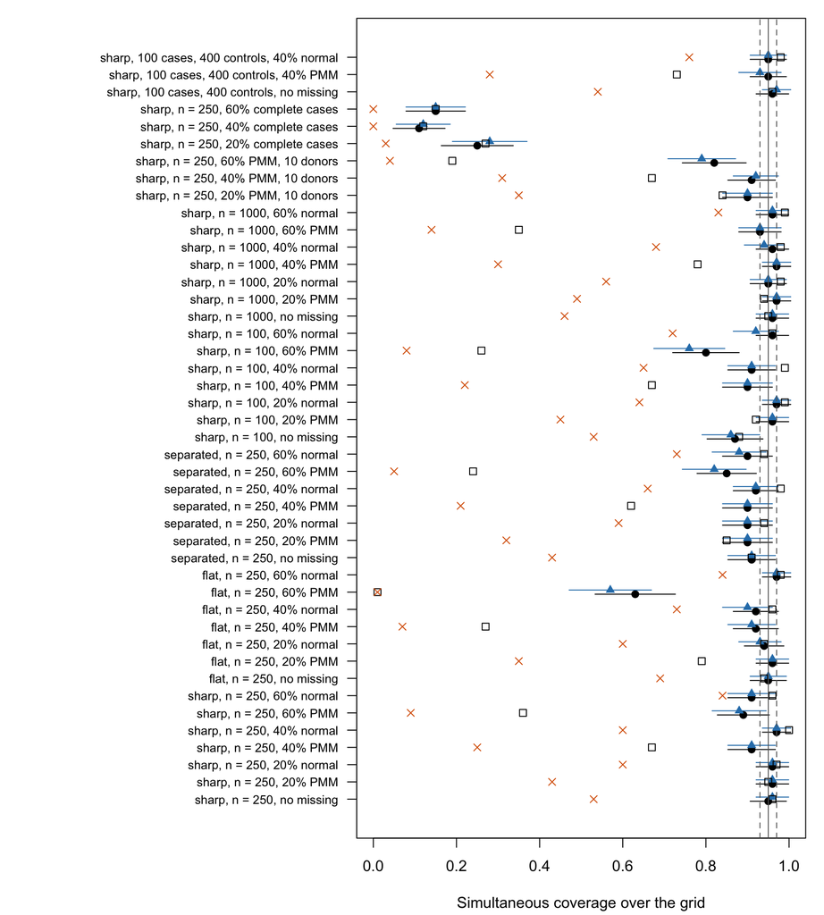

Figure 1: Simultaneous coverage of the whole Youden curve over the grid, in every cell: the bootstrap band (black circles) and the hybrid band (blue triangles), each with plus and minus two Monte Carlo standard errors; the Rubin’s-rules band (open squares); and the pointwise Rubin’s intervals read as a band (orange crosses). The solid line is the nominal 95%; the dashed lines are 0.93 and 0.97. Rows name the shape, the group size, the missing fraction, and the imputation: PMM is predictive mean matching (five donors unless stated), normal is normal imputation.

Table 2: Why the bands fall short: the averaged curve at the grid’s best threshold, sharp shape, 250 per group. Bias is the mean of the averaged curve minus the true curve there, with its Monte Carlo standard error (MCSE). SD / SE is the Monte Carlo standard deviation of that difference over its mean standard error, from the bootstrap-then-impute covariance or from Rubin’s rules; a ratio above one means the standard error is too small. PMM is predictive mean matching; every cell of every arm is in Table S1.

| Cell | Bias at the best threshold | MCSE | SD / SE, bootstrap | SD / SE, Rubin | Hybrid band coverage |
| --- | --- | --- | --- | --- | --- |
| sharp, n = 250, 20% PMM | 0.0028 | 0.0033 | 0.97 | 0.96 | 0.960 |
| sharp, n = 250, 20% PMM, 10 donors | 0.0020 | 0.0036 | 1.07 | 1.07 | 0.900 |
| sharp, n = 250, 20% normal | -0.0024 | 0.0035 | 1.05 | 1.01 | 0.960 |
| sharp, n = 250, 40% PMM | -0.0085 | 0.0041 | 1.00 | 1.07 | 0.910 |
| sharp, n = 250, 40% PMM, 10 donors | -0.0106 | 0.0044 | 1.03 | 1.13 | 0.920 |
| sharp, n = 250, 40% normal | -0.0042 | 0.0038 | 1.08 | 0.98 | 0.970 |
| sharp, n = 250, 60% PMM | -0.0087 | 0.0066 | 1.10 | 1.40 | 0.880 |
| sharp, n = 250, 60% PMM, 10 donors | -0.0292 | 0.0061 | 0.92 | 1.27 | 0.790 |
| sharp, n = 250, 60% normal | -0.0017 | 0.0037 | 0.84 | 0.78 | 0.910 |

### 3.2.2 The near-optimal sets

The hybrid comparison-based set held the grid’s best threshold in 0.93 to 1.00 (MCSE at most 0.026) of replicates across all cells, and the bootstrap one in 0.93 to 1.00 (MCSE at most 0.026) (Figure 2). The hybrid set’s length was 0.33 to 0.72 of the band-based set’s, and 1.4 to 4.9 times the length of the true range of thresholds whose index is within 0.01 of $J^*$. Without missing values in the sharp shape, its length fell from 1.37 at 100 per group to 0.66 at 1,000. The plug-in critical value, 2.54 to 2.75 across cells against 2.61 to 2.78 for the largest per-point quantile, shortened the hybrid set to 0.33 to 0.70 of the band-based set’s length, and that set held the best threshold in 0.91 to 1.00 (MCSE at most 0.029) of replicates.

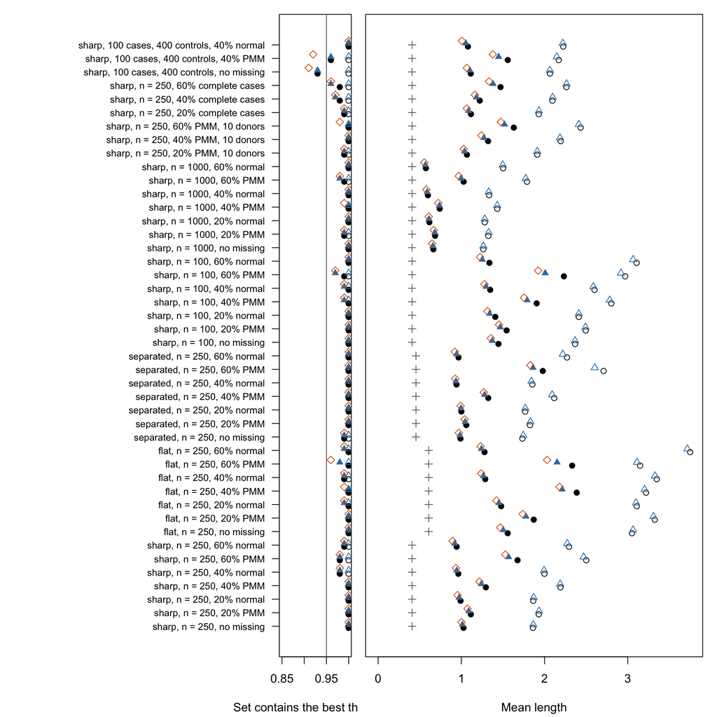

Figure 2: The near-optimal sets in every cell. Left: the share of replicates in which a set holds the grid’s best threshold; right: its mean length on the marker’s scale. Comparison-based sets are filled (bootstrap black circles, hybrid blue triangles), band-based sets open, and the hybrid comparison-based set with the plug-in critical value is an orange diamond; grey crosses mark the length of the true range of thresholds whose index is within 0.01 of $J^*$. The vertical line is the nominal 95%.

### 3.2.3 The corrected index

Without missing values the reported index exceeded the true accuracy of the chosen threshold by 0.013 to 0.043 (MCSE at most 0.005) (Figure 3). For the sharp shape the optimism fell with group size, from 0.043 (MCSE 0.0050) at 100 per group to 0.013 (MCSE 0.0016) at 1,000, a slope of -0.52 (MCSE 0.073) on the log scale TO CONFIRM: the slope lies between minus one half and the minus two thirds of Supplementary note S1.2 within the precision of 100 replicates. The correction with 20 imputations per resample left 0.001 to 0.013 (MCSE at most 0.006) in those cells. With normal imputation the optimism was 0.002 to 0.039 (MCSE at most 0.006) and the corrected index’s bias -0.006 to 0.014 (MCSE at most 0.007). With predictive mean matching the corrected index’s bias was -0.053 to 0.015 (MCSE at most 0.010), lowest where the averaged curve was most biased. The correction with 2 imputations per resample had a bias of -0.057 to 0.013 (MCSE at most 0.011) across all cells.

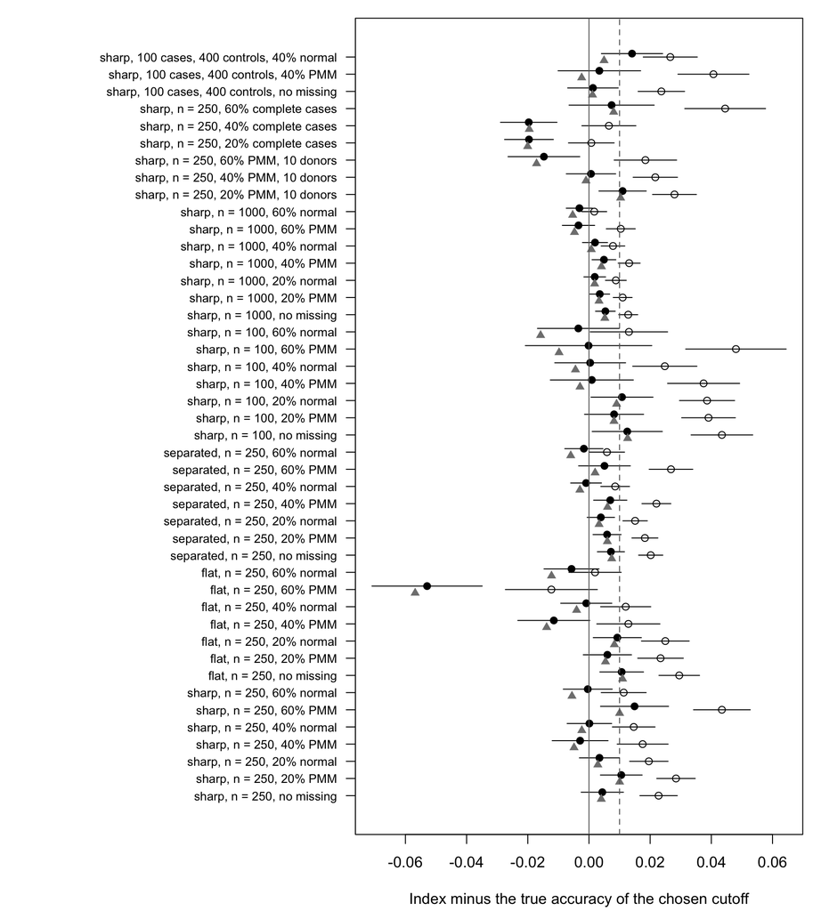

Figure 3: The reported index against the true accuracy of the chosen threshold, in every cell: the mean optimism of the reported index (open circles), the bias of the corrected index with 20 imputations per resample (filled circles), each with plus and minus two Monte Carlo standard errors, and the bias of the corrected index with 2 imputations per resample (grey triangles). The solid line is zero; the dashed line is 0.01.

### 3.2.4 The order of pooling

Maximizing in each completed dataset first raised the index above the pooled maximum by 0.0004 to 0.0161 (MCSE at most 0.001) in the cells with imputed values (Figure 4). The gap was 0.52 to 0.95 times the mean of $\kappa \hat B_c / 2$ under predictive mean matching and 0.61 to 1.82 times under normal imputation. The averaged cutoff’s root mean squared error was 0.72 to 0.90 of the pooled cutoff’s, and the bagged cutoff’s 0.60 to 0.94 (Table S2).

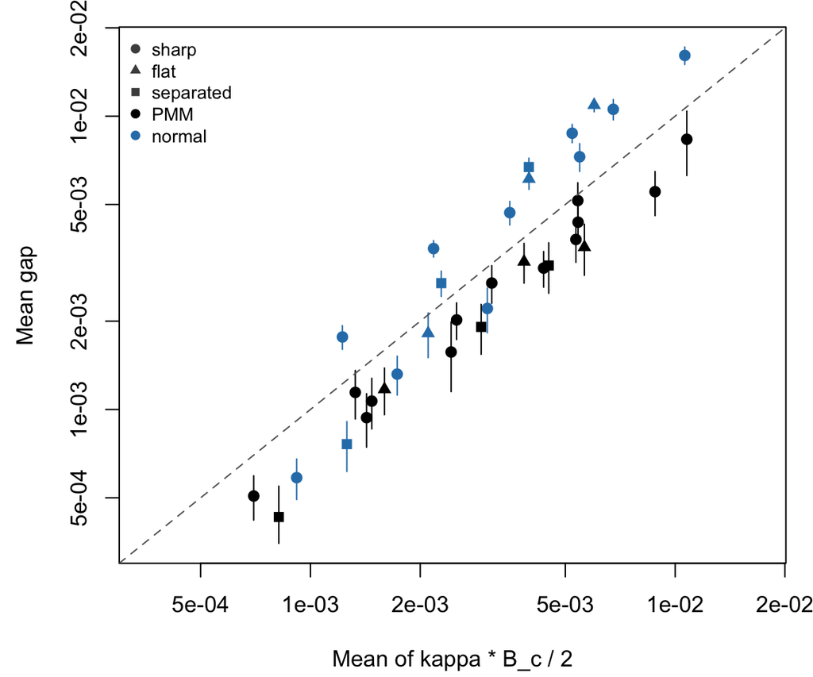

Figure 4: The order of pooling: the mean gap between the index from maximizing in each completed dataset first and the index of the pooled curve, against the mean of its quadratic approximation $\kappa \hat B_c / 2$, one point per cell with imputed values, with plus and minus two Monte Carlo standard errors. Circles, triangles, and squares are the sharp, flat, and separated shapes; black is predictive mean matching, blue normal imputation. The dashed line is equality.

# 4 Application

## 4.1 Data and comparison

The application asks the question of the Introduction on real data: which serum cotinine threshold separates people who smoke cigarettes from people who do not, and how sure can a study be of it, when cotinine is missing for some participants. The cohort, its definitions, and the imputation model are in the Methods. Of the 17,948 adults, 3,353 were current smokers, and cotinine was missing for 10.0% of smokers and 9.4% of nonsmokers. Table 3 places the data on the simulation’s gradients: the complete-case curve is as high as the separated shape’s and as flat at its peak as the flat shape’s, the groups are larger than the largest simulated size, and the real missing fraction, spread evenly over the two groups, is below the smallest simulated one, which falls on the cases above all.

Table 3: Where the NHANES data sit on the simulation’s gradients. $J^*$ and $\kappa$ are the maximum and the curvature at the peak of the complete-case curve, the curvature on the scale of log10 cotinine standardized by the nonsmokers’ mean and standard deviation (the simulation’s scale); the simulation’s values are those of the sharp, flat, and separated shapes; $n$ is the number of participants in each group.

| Quantity | Symbol | NHANES | Simulation |
| --- | --- | --- | --- |
| Maximum of the Youden curve | $J^*$ | 0.87 | 0.68, 0.44, 0.87 |
| Curvature at the peak (standardized scale) | $\kappa$ | 0.23 | 0.48, 0.22, 0.39 |
| Participants per group | $n$ | 3,353 smokers, 14,595 nonsmokers | 100, 250, 1,000 |
| Missing fraction |  | 9.4% of nonsmokers and 10.0% of smokers (real); 40% overall (imposed) | 0%, 20%, 40%, 60% overall; at 20%, 6% of controls and 34% of cases (sharp shape) |
| Cases to controls |  | 1 to 4.4 | 1 to 1; 1 to 4 |

## 4.2 The data cannot choose between the published cutoff and the cohort’s own

With the real missing values imputed, the pooled curve peaked at 7.37 ng/mL, where its index was 0.867 (Figure 5, left). The matched correction lowered the index by 0.0013, to 0.866. The comparison-based set of the hybrid construction ran from 3.43 to 11.95 ng/mL, and that of the bootstrap construction was the same; the band-based set ran from 0.77 to 25.27 ng/mL. The adult cutoff of 3.63 ng/mL published from the 2009 to 2014 cycles<sup>2</sup> lay inside every set. A study that reports the cohort’s optimum as the cutoff therefore reports one point of a range that the data cannot narrow further, and the published cutoff, whose complete-case index is lower by 0.003, is as well supported.

With 39.8% of the complete cases’ cotinine values set missing at random, depending on smoking status, age, and sex only, a weaker dependence than the simulation’s, the analysis recovered the complete-case curve (Figure 5, right). The bootstrap band, the hybrid band, the Rubin’s-rules band, and even the pointwise intervals contained the complete-case curve at every grid point, and every set held the complete-case curve’s best grid threshold. The reported index, 0.874, exceeded the complete-case curve at the chosen threshold, 0.868, by 0.006, and the correction removed 0.0001 of it. The comparison-based set ran from 1.64 to 15.61 ng/mL with the hybrid construction and from 1.64 to 15.61 ng/mL with the bootstrap one, and the band-based set from 0.60 to 33.08 ng/mL.

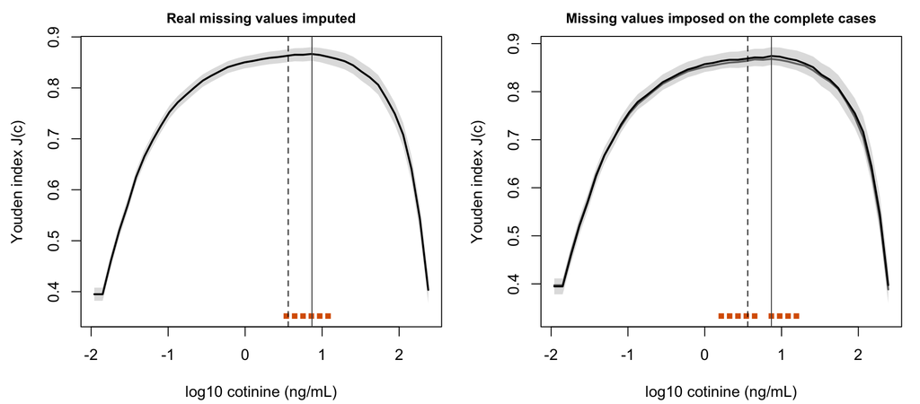

Figure 5: The NHANES pooled Youden curve of log10 cotinine (black), its hybrid band (grey), the chosen threshold (solid vertical line), the hybrid comparison-based set (orange squares at the bottom), and the published adult cutoff of 3.63 ng/mL (dashed). Left: the real missing values imputed. Right: missing values imposed at random on the complete cases, with the complete-case curve in grey.

By race/ethnicity, the stratum-specific cutoffs ranged from 0.63 to 25.00 ng/mL (Table 4), and the published cutoff lay in the comparison-based set of 5 of the 6 groups. The population-optimal cutoff differed from the stratum-specific one in 4 groups, upward where the group held a larger share of the nonsmokers than of the smokers and downward where it held a smaller share, as S1.6 predicts.

Table 4: Cutoffs by race/ethnicity, each from the analysis run within the group with its missing values imputed. The stratum-specific cutoff maximizes the group’s own Youden curve; the population-optimal cutoff maximizes the group’s contribution to the Youden index of a rule with one cutoff per group (Supplementary note S1.6). The set is the hybrid comparison-based set; the index is the group’s reported maximum and its matched correction.

| Race/ethnicity | Smokers | Nonsmokers | Stratum-specific cutoff (ng/mL) | Population-optimal cutoff (ng/mL) | Comparison-based set (ng/mL) | Index, reported and corrected |
| --- | --- | --- | --- | --- | --- | --- |
| Mexican American | 354 | 2,347 | 0.63 | 0.63 | 0.20 to 4.42 | 0.841 and 0.834 |
| Non-Hispanic Asian | 193 | 2,088 | 0.66 | 3.95 | 0.38 to 23.18 | 0.897 and 0.886 |
| Non-Hispanic Black | 907 | 2,950 | 25.00 | 25.00 | 8.41 to 64.83 | 0.863 and 0.860 |
| Non-Hispanic White | 1,447 | 5,066 | 9.12 | 4.83 | 2.30 to 22.76 | 0.871 and 0.869 |
| Other Hispanic | 246 | 1,634 | 2.05 | 6.78 | 0.56 to 22.44 | 0.877 and 0.867 |
| Other or multiracial | 206 | 510 | 22.19 | 1.78 | 1.38 to 48.83 | 0.851 and 0.835 |

# 5 Discussion

For a study that imputes a missing marker and reports a cutoff, three changes follow. Report the pooled curve with its band and the comparison-based set, so that readers see the range of thresholds the data support, as in the cotinine example, where the published cutoff and the cohort’s own both fell in the set. Report the corrected index beside the maximum. And treat the imputation model as part of the inference: the bootstrap-then-impute covariance tracked the curve’s variance in every cell, so a band that undercovers points to imputations that are biased near the threshold, which ten donors, the pool recommended against sparse donors<sup>29</sup>, did not fix, and which a correctly specified model avoided TO CONFIRM: this reading rests on the normal engine being the correct model in the simulation; no misspecified parametric model was tried. Complete cases are not an alternative when missingness depends on the marker’s correlates: their bands missed the curve in most replicates.

Table 5: What was known and what this paper adds. MI is multiple imputation.

| Element | Prior literature | This paper |
| --- | --- | --- |
| The pooled Youden curve from MI data | curves averaged across completed datasets, a threshold read off without uncertainty<sup>5</sup> | a band, a near-optimal set, and a corrected index for it |
| A simultaneous band for the curve | sup-t bands in general<sup>21</sup>; complete-data intervals for the index and the threshold<sup>11</sup> | a bootstrap-then-impute sup-t band, with the covariance split from two imputations to the analysis’s twenty |
| A set of near-optimal thresholds | multiple comparisons with the best<sup>22</sup>; confidence regions at the estimated threshold<sup>12</sup> | a set built from comparisons between thresholds on the pooled curve, narrower than the set a band gives |
| The optimism of the reported index | the empirical index biased upward without missing data<sup>10</sup> | a correction that repeats the imputation as the analysis does, measured under MI |
| The order of pooling | propensity scores<sup>15,30,31</sup>, variable selection<sup>32</sup>, and predictions<sup>33</sup> across completed datasets | the gap for the Youden index and its quadratic form, measured |
| The bootstrap with MI | which combinations are valid<sup>4,34</sup>, few imputations per resample<sup>23</sup> | applied to a whole curve and to a non-regular maximum |

Several features of the simulation limit what it shows. The marker was binormal, while real markers are skewed or, like cotinine below its limit of detection, carry a point mass; the application has one, the simulation does not. The auxiliary’s strength and the missingness coefficients were fixed, so the band’s shortfall under predictive mean matching was measured at one level of donor sparsity per missing fraction. The imputation model had one auxiliary and, for the normal engine, was correctly specified; real imputation models carry several covariates and are misspecified to some degree. Missingness was at random given the auxiliary and the disease status, and missingness that depends on the marker’s own value is corrected by neither engine. The covariance was always estimated from two imputations per resample and rescaled, and the number of resamples and of imputations per resample was not varied. The set’s guarantee is for the grid’s best threshold, not for $c^*$ itself, and the grid had one resolution.

Several directions lie outside this paper. A second dataset is needed to test the procedure on a marker with another shape. A continuous covariate turns the stratum-specific cutoffs of the application into a covariate-specific curve<sup>35,36</sup>. When the disease status rather than the marker is missing, the same questions arise under verification bias<sup>16,17</sup>. Criteria other than the Youden index, such as a target sensitivity, need their own sets. A bootstrap with a theory for cube-root estimators<sup>13</sup>, carried through imputation, is the candidate for removing the optimism the plain correction leaves. A software release of the procedure, and a short reporting guide for applied studies that impute a marker and report a cutoff, are the steps that make the procedure usable.

# Acknowledgements

Generative AI was used in this work, and because it shaped the methods, the analysis, and the results, it is disclosed here as the publisher’s policy requires. An AI assistant (Claude, Anthropic) drafted the code, proposed the structure of the simulation study, summarized the literature, and produced a first draft of the text. The authors reviewed, corrected, and take responsibility for every part of the manuscript. Every derivation was checked numerically, by a unit test or by the simulation, and every citation rests on a passage of the cited paper recorded with the date it was read. No AI tool is an author.

# Statements and declarations

TO CONFIRM: the journal requires a Statements and Declarations section with each of its subheadings present, even when not applicable; the subheadings are not listed in the journal’s profile

*Data availability.* The NHANES data are public, from the survey’s data pages CITE: the NHANES 2013 to 2018 data files (no item in Zotero). The code, the results, and this manuscript form a research compendium<sup>27</sup>: an R package whose tested functions the analysis scripts call, and which this document reads at render time. TO CONFIRM: the repository URL, withheld while review is double-anonymized

# References

1.

Benowitz NL, Bernert JT, Caraballo RS, et al. [Optimal serum cotinine levels for distinguishing cigarette smokers and nonsmokers within different racial/ethnic groups in the United States between 1999 and 2004](https://doi.org/10.1093/aje/kwn301). *American Journal of Epidemiology* 2009; 169: 236–248.

2.

Tompkins EL, Beltran TA, Bedno SA. [Differentiating Between Smokers and Nonsmokers Using Serum Cotinine](https://doi.org/10.2217/bmm-2019-0027). *Biomarkers in Medicine* 2019; 13: 1025–1033.

3.

Hassanzad M, Hajian-Tilaki K. [Methods of determining optimal cut-point of diagnostic biomarkers with application of clinical data in ROC analysis: An update review](https://doi.org/10.1186/s12874-024-02198-2). *BMC Medical Research Methodology* 2024; 24: 84.

4.

Bartlett JW, Hughes RA. [Bootstrap inference for multiple imputation under uncongeniality and misspecification](https://doi.org/10.1177/0962280220932189). *Statistical Methods in Medical Research* 2020; 29: 3533–3546.

5.

Long Q, Zhang X, Hsu C. [Nonparametric multiple imputation for receiver operating characteristics analysis when some biomarker values are missing at random](https://doi.org/10.1002/sim.4338). *Statistics in Medicine* 2011; 30: 3149–3161.

6.

Abdulrahman H, Jansen E, Hoevenaar-Blom M, et al. [Diagnostic accuracy of the telephone interview for cognitive status for the detection of dementia in primary care](https://doi.org/10.1370/afm.2768). *The Annals of Family Medicine* 2022; 20: 130–136.

7.

Atlantis E, Fahey P, Martin S, et al. [Predictive value of serum testosterone for type 2 diabetes risk assessment in men](https://doi.org/10.1186/s12902-016-0109-7). *BMC Endocrine Disorders* 2016; 16: 26.

8.

Wirth M, Ruckes C, Michel M, et al. [Development and validation of a multivariable risk prediction model for hepatic steatosis in patients with HIV infection](https://doi.org/10.1097/QAD.0000000000003779). *AIDS* 2024; 38: 447–454.

9.

Thiele C, Hirschfeld G. [Confidence intervals and sample size planning for optimal cutpoints](https://doi.org/10.1371/journal.pone.0279693). *plos one* 2023; 18: e0279693.

10.

Fluss R, Faraggi D, Reiser B. [Estimation of the Youden Index and its Associated Cutoff Point](https://doi.org/10.1002/bimj.200410135). *Biometrical Journal* 2005; 47: 458–472.

11.

Bantis LE, Nakas CT, Reiser B. [Construction of confidence intervals for the maximum of the Youden index and the corresponding cutoff point of a continuous biomarker](https://doi.org/10.1002/bimj.201700107). *Biometrical Journal* 2019; 61: 138–156.

12.

Bantis LE, Nakas CT, Reiser B. [Construction of confidence regions in the ROC space after the estimation of the optimal Youden index-based cut-off point](https://doi.org/10.1111/biom.12107). *Biometrics* 2014; 70: 212–223.

13.

Cattaneo MD, Jansson M, Nagasawa K. [Bootstrap‐Based Inference for Cube Root Asymptotics](https://doi.org/10.3982/ECTA17950). *Econometrica* 2020; 88: 2203–2219.

14.

Wang S, Fang F, Li J. [Optimal Linear Combination of Biomarkers by Weighted Youden Index Maximization](https://doi.org/10.1002/sim.70182). *Statistics in Medicine* 2025; 44: e70182.

15.

Leyrat C, Seaman SR, White IR, et al. [Propensity score analysis with partially observed covariates: How should multiple imputation be used?](https://doi.org/10.1177/0962280217713032) *Statistical Methods in Medical Research* 2019; 28: 3–19.

16.

Fluss R, Reiser B, Faraggi D, et al. [Estimation of the ROC Curve under Verification Bias](https://doi.org/10.1002/bimj.200800128). *Biometrical Journal* 2009; 51: 475–490.

17.

Wang S, Shi S, Qin G. [Interval estimation for the Youden index of a continuous diagnostic test with verification biased data](https://doi.org/10.1177/09622802251322989). *Statistical Methods in Medical Research* 2025; 34: 796–811.

18.

Jia S, Wang S, Qin G. [Methodological Approaches for the Estimation of Confidence Intervals on Partial Youden Index Under Verification Bias](https://doi.org/10.1002/pst.70079). *Pharmaceutical Statistics* 2026; 25: e70079.

19.

Karakaya J, Karabulut E, Yucel RM. [Sensitivity to imputation models and assumptions in receiver operating characteristic analysis with incomplete data](https://doi.org/10.1080/00949655.2014.983111). *Journal of Statistical Computation and Simulation* 2015; 85: 3498–3511.

20.

Cheng W, Tang N. [Smoothed empirical likelihood inference for ROC curve in the presence of missing biomarker values](https://doi.org/10.1002/bimj.201900121). *Biometrical Journal* 2020; 62: 1038–1059.

21.

Montiel Olea JL, Plagborg‐Møller M. [Simultaneous confidence bands: Theory, implementation, and an application to SVARs](https://doi.org/10.1002/jae.2656). *Journal of Applied Econometrics* 2019; 34: 1–17.

22.

Hsu JC. *Multiple comparisons: Theory and methods*. CRC Press, 1996.

23.

Von Hippel PT, Bartlett JW. [Maximum Likelihood Multiple Imputation: Faster Imputations and Consistent Standard Errors Without Posterior Draws](https://doi.org/10.1214/20-STS793). *Statistical Science* 2021; 36: 400–420.

24.

Rubin DB. *Multiple Imputation for Nonresponse in Surveys*. Chapman; Hall/CRC, 1987.

25.

Zhang Z, Shi X, Xiang X, et al. [Bootstrap confidence intervals for the optimal cutoff point to bisect estimated probabilities from logistic regression](https://doi.org/10.1177/0962280219864998). *Statistical Methods in Medical Research* 2020; 29: 1514–1526.

26.

Buuren S van, Groothuis-Oudshoorn K. [Mice: Multivariate Imputation by Chained Equations in R](https://doi.org/10.18637/jss.v045.i03). *Journal of Statistical Software* 2011; 45: 1–67.

27.

Marwick B, Boettiger C, Mullen L. [Packaging Data Analytical Work Reproducibly Using R (and Friends)](https://doi.org/10.1080/00031305.2017.1375986). *The American Statistician* 2018; 72: 80–88.

28.

Morris TP, White IR, Crowther MJ. [Using simulation studies to evaluate statistical methods](https://doi.org/10.1002/sim.8086). *Statistics in Medicine* 2019; 38: 2074–2102.

29.

Morris TP, White IR, Royston P. [Tuning multiple imputation by predictive mean matching and local residual draws](https://doi.org/10.1186/1471-2288-14-75). *BMC Medical Research Methodology* 2014; 14: 75.

30.

Mitra R, Reiter JP. [A comparison of two methods of estimating propensity scores after multiple imputation](https://doi.org/10.1177/0962280212445945). *Statistical Methods in Medical Research* 2016; 25: 188–204.

31.

Granger E, Sergeant JC, Lunt M. [Avoiding pitfalls when combining multiple imputation and propensity scores](https://doi.org/10.1002/sim.8355). *Statistics in Medicine* 2019; 38: 5120–5132.

32.

Wood AM, White IR, Royston P. [How should variable selection be performed with multiply imputed data?](https://doi.org/10.1002/sim.3177) *Statistics in Medicine* 2008; 27: 3227–3246.

33.

Mertens BJA, Burg LLJ van der, Donal E, et al. [Predictive averaging and Rubin’s rule-based model pooling to predict survival risk with imputations in the presence of missing patient data: Methodology and verification using two case studies and simulations](https://doi.org/10.1186/s12874-026-02888-z). *BMC Medical Research Methodology* 2026; 26: 180.

34.

Schomaker M, Heumann C. [Bootstrap inference when using multiple imputation](https://doi.org/10.1002/sim.7654). *Statistics in Medicine* 2018; 37: 2252–2266.

35.

Inácio De Carvalho V, De Carvalho M, Branscum AJ. [Nonparametric Bayesian Covariate-Adjusted Estimation of the Youden Index](https://doi.org/10.1111/biom.12686). *Biometrics* 2017; 73: 1279–1288.

36.

Xu T, Wang J, Fang Y. [A model‐free estimation for the covariate‐adjusted Youden index and its associated cut‐point](https://doi.org/10.1002/sim.6290). *Statistics in Medicine* 2014; 33: 4963–4974.

# Supplementary note S1

This note derives the six results the paper uses: why the reported index overstates the chosen threshold’s accuracy, how fast that excess shrinks, how far maximizing first moves the index, why the covariance split targets the analysis’s own estimate, why the comparison-based set holds the best threshold, and why one cutoff per stratum can be chosen stratum by stratum. Each is short, and each is checked by a test in the package or by the simulation.

Notation: $J$, $c^*$, $J^*$, $\bar J$, $\hat c$, $\hat J_l$, $\hat c_l$, $\Sigma$, $V$, $W$, $M$, $L$, and $\mathrm{SE}_{jk}$ are as in the Methods, and $n$ is the size of each group.

### S1.1 The reported index is optimistic

If the pooled curve is unbiased at the best threshold, $\mathrm{E}\{\bar J(c^*)\} = J^*$, then the reported index exceeds the accuracy of the chosen threshold in expectation:
$$\begin{aligned}
\max_c \bar J(c) &\ge \bar J(c^*), \\
\mathrm{E}\{\max_c \bar J(c)\} &\ge \mathrm{E}\{\bar J(c^*)\} = J^*, \\
J^* &\ge J(\hat c), \\
\mathrm{E}\{\max_c \bar J(c)\} - \mathrm{E}\{J(\hat c)\} &\ge 0 .
\end{aligned}$$
Line 1 holds in every dataset, since a maximum is at least the value at any point. Line 2 takes expectations and uses the premise. Line 3 holds because $J^*$ is the maximum of $J$. Line 4 combines lines 2 and 3. The premise fails when the imputations are biased, which is the case the predictive-mean-matching cells probe. The paper uses the result in the Introduction and the Methods; the test that `RunReplicateC()` returns a maximum at least the curve’s value at the chosen threshold checks the first line in code, and the null cells of the simulation show the excess with nothing missing.

### S1.2 The excess is of order $n^{-2/3}$ (a sketch)

This is a sketch, not a proof. Assume complete data, a unique maximum with curvature $\kappa = -J''(c^*) > 0$, and positive densities at $c^*$. The empirical threshold maximizes a sum of indicator functions, the setting of cube-root asymptotics: $n^{1/3}(\hat c - c^*)$ converges to the maximizer of a Gaussian process with a quadratic drift CITE: the cube-root limit (Kim and Pollard 1990; no readable text in Zotero)<sup>13</sup>. Write $G = \bar J - J$ for the centred curve. Then
$$\begin{aligned}
\max_c \bar J(c) - J(\hat c) &= \{\max_c \bar J(c) - \bar J(\hat c)\} + G(\hat c), \\
G(\hat c) &= G(c^*) + \{G(\hat c) - G(c^*)\}, \\
\mathrm{E}\{G(c^*)\} &= 0, \\
G(\hat c) - G(c^*) &= O_p(n^{-1/2} \lvert \hat c - c^* \rvert^{1/2}) = O_p(n^{-2/3}).
\end{aligned}$$
Line 1 adds and subtracts $\bar J(\hat c)$; the braced term is zero when the maximum is reached at $\hat c$, and of lower order when tied intervals lie apart. Line 2 adds and subtracts $G(c^*)$. Line 3 holds because $\bar J(c^*)$ is an average of unbiased proportions. Line 4 uses the modulus of continuity of the empirical process, whose increment over a distance $\delta$ has standard deviation of order $(\delta / n)^{1/2}$, with $\delta = O_p(n^{-1/3})$. The excess is therefore of order $n^{-2/3}$ in expectation, given uniform integrability, which the sketch assumes. A full derivation must also carry the imputation: proper imputation with an unbiased model inflates the variance of $G$ without changing its order. The paper uses the order in the Methods; the simulation’s size gradient checks it, since the optimism at the three sizes of the sharp shape should fall along a line of slope near $-2/3$ on the log scale.

### S1.3 The order of pooling

The mean of the per-dataset maxima is never below the maximum of the mean curve, and for curves that are quadratic near their peaks the gap is close to $\kappa \hat B_c / 2$:
$$\begin{aligned}
\hat J_l(c) &\le \max_{c'} \hat J_l(c') \quad \text{for every } c, l, \\
\bar J(c) &\le L^{-1} \textstyle\sum_l \max_{c'} \hat J_l(c') \quad \text{for every } c, \\
\max_c \bar J(c) &\le L^{-1} \textstyle\sum_l \max_{c'} \hat J_l(c'), \\
\hat J_l(c) &= m_l - (\kappa_l / 2)(c - \hat c_l)^2 \quad \text{near the peaks}, \\
\arg\max_c \bar J(c) &= \tilde c_\kappa = \textstyle\sum_l \kappa_l \hat c_l / \sum_l \kappa_l, \\
L^{-1} \textstyle\sum_l m_l - \max_c \bar J(c) &= L^{-1} \textstyle\sum_l (\kappa_l / 2)(\hat c_l - \tilde c_\kappa)^2 .
\end{aligned}$$
Line 1 is the definition of a maximum. Line 2 averages line 1 over $l$. Line 3 maximizes the left side of line 2 over $c$, so the gap is never negative; it is zero when one threshold maximizes every curve, as in the cells without missing values. Line 4 is the quadratic approximation, valid for smooth curves with every per-dataset cutoff in the region where it holds. Line 5 sets the derivative of the averaged quadratic to zero. Line 6 substitutes line 5 into the averaged quadratic. With equal curvatures $\kappa_l = \kappa$, the right side of line 6 is $\kappa \hat B_c / 2$. The empirical curve is a step function and has no curvature, so for it the formula is an approximation that the simulation compares with the observed gap. The paper uses the result in the Methods and the note on the order of pooling; the unit tests of the pooling rules check lines 1 to 3 on curves in code (a gap of exactly zero for identical curves), and the package’s known-answer tests on synthetic quadratic curves find line 6 to machine precision.

### S1.4 The covariance split

Write the $m$-th imputed curve of resample $b$ as $\hat J_{bm} = A_b + e_{bm}$, with $A_b$ the curve the resample would give with infinitely many imputations and $e_{bm}$ the imputation noise, independent across $m$ given the resample, with mean zero and covariance $W$. Then
$$\begin{aligned}
\bar J_b &= A_b + M^{-1} \textstyle\sum_m e_{bm}, \\
\mathrm{Cov}(\bar J_b) &= \mathrm{Cov}(A_b) + W / M = V, \\
\mathrm{E}\{(M-1)^{-1} \textstyle\sum_m (\hat J_{bm} - \bar J_b)(\hat J_{bm} - \bar J_b)^\top\} &= W, \\
\mathrm{Cov}(A_b) + W / L &= V - W / M + W / L .
\end{aligned}$$
Line 1 averages the $M$ imputations. Line 2 uses the independence of the noise from $A_b$ and across imputations. Line 3 is the unbiasedness of the sample covariance of $M$ draws about their mean. Line 4 is the covariance of an estimate built from $L$ imputations, written in terms of what the resamples estimate; with $L > M$ it is smaller than $V$. The bootstrap supplies $\mathrm{Cov}(A_b)$ as the sampling covariance of the data’s own curve when the resample mimics the sample<sup>4</sup>. The paper uses the result for both bands and both sets; the known-answer test of the covariance split, on synthetic resamples with known parts, checks a diagonal and an off-diagonal entry.

### S1.5 The comparison-based set holds the best threshold

Let $k^*$ be the grid point with the largest $J(c_k)$. If every comparison of $k^*$ with another grid point is within its bound,
$$\begin{aligned}
\{\bar J(c_j) - \bar J(c_{k^*})\} - \{J(c_j) - J(c_{k^*})\} &\le q_D\,\mathrm{SE}_{jk^*} \quad \text{for every } j \ne k^*, \\
J(c_j) - J(c_{k^*}) &\le 0, \\
\bar J(c_j) - \bar J(c_{k^*}) &\le q_D\,\mathrm{SE}_{jk^*},
\end{aligned}$$
then $k^* \in S_C$. Line 1 is the event. Line 2 holds because $k^*$ is best. Line 3 adds lines 1 and 2, which is the condition for membership. The event of line 1 has probability 95% in the limit when the differences are jointly normal with covariance from $\Sigma$ and $q_D \ge q_{k^*}$; the largest per-point quantile $q_D = \max_k q_k$ meets that whichever point is best. The plug-in value $q_{\hat k}$ equals $q_{k^*}$ when $\hat k = k^*$ and otherwise carries no guarantee. The paper uses the result in the Methods; the known-answer tests check the critical value for two independent coordinates, $\Phi^{-1}(0.95)$, and that a set built on the true curve holds the best grid point.

### S1.6 One cutoff per stratum

A rule that calls a person positive when $X > c(V)$, with one cutoff for each value $v$ of a discrete covariate $V$, has Youden index
$$\begin{aligned}
J_{\mathrm{rule}} &= P\{X \le c(V) \mid D = 0\} - P\{X \le c(V) \mid D = 1\} \\
&= \textstyle\sum_v \{w_0(v) F_0(c(v) \mid v) - w_1(v) F_1(c(v) \mid v)\},
\end{aligned}$$
with $w_d(v) = P(V = v \mid D = d)$. Line 1 is the definition. Line 2 conditions on $V$. Each term of the sum depends on one cutoff only, so the rule is maximized term by term, and the population-optimal cutoff of stratum $v$ maximizes $w_0(v) F_0(c \mid v) - w_1(v) F_1(c \mid v)$. With densities, its first-order condition is $w_0(v) f_0(c \mid v) = w_1(v) f_1(c \mid v)$, while the stratum’s own Youden cutoff solves $f_0(c \mid v) = f_1(c \mid v)$. The two agree when $w_0(v) = w_1(v)$. At the stratum’s own cutoff the derivative of the population criterion is $\{w_0(v) - w_1(v)\} f_0(c \mid v)$, so a stratum that holds a larger share of the controls than of the cases has a population-optimal cutoff above its own, for a curve with one peak. The paper uses the result in the application; the tests of `StratumCutoffs()` check that equal shares give the stratum’s own cutoff and that a larger share of controls does not lower it.

### S1.7 Every cell of the simulation

Table S1 gives, for every cell of the simulation study, the measures of the bands, the sets, and the index that the Results report, and Table S2 the measures of the threshold and the order of pooling.

| Cell | Hybrid band | Bootstrap band | Rubin band | Set holds best | Set length | Optimism | Corrected bias | Curve bias at best | SD / SE |
| --- | --- | --- | --- | --- | --- | --- | --- | --- | --- |
| sharp, n = 250, no missing | 0.96 | 0.95 | 0.96 | 1.00 | 1.01 | 0.023 | 0.004 | -0.002 | 1.05 |
| sharp, n = 250, 20% PMM | 0.96 | 0.96 | 0.95 | 1.00 | 1.09 | 0.028 | 0.011 | 0.003 | 0.97 |
| sharp, n = 250, 20% normal | 0.96 | 0.96 | 0.97 | 1.00 | 0.97 | 0.020 | 0.003 | -0.002 | 1.05 |
| sharp, n = 250, 40% PMM | 0.91 | 0.91 | 0.67 | 1.00 | 1.24 | 0.018 | -0.003 | -0.008 | 1.00 |
| sharp, n = 250, 40% normal | 0.97 | 0.97 | 1.00 | 0.98 | 0.94 | 0.015 | 0.000 | -0.004 | 1.08 |
| sharp, n = 250, 60% PMM | 0.88 | 0.89 | 0.36 | 0.98 | 1.57 | 0.043 | 0.015 | -0.009 | 1.10 |
| sharp, n = 250, 60% normal | 0.91 | 0.91 | 0.96 | 0.99 | 0.92 | 0.011 | -0.000 | -0.002 | 0.84 |
| flat, n = 250, no missing | 0.95 | 0.95 | 0.94 | 1.00 | 1.50 | 0.030 | 0.011 | 0.006 | 0.95 |
| flat, n = 250, 20% PMM | 0.96 | 0.96 | 0.79 | 1.00 | 1.78 | 0.023 | 0.006 | 0.001 | 1.06 |
| flat, n = 250, 20% normal | 0.93 | 0.94 | 0.94 | 0.99 | 1.45 | 0.025 | 0.009 | 0.003 | 1.09 |
| flat, n = 250, 40% PMM | 0.91 | 0.92 | 0.27 | 1.00 | 2.21 | 0.013 | -0.011 | -0.033 | 1.01 |
| flat, n = 250, 40% normal | 0.90 | 0.92 | 0.96 | 0.99 | 1.26 | 0.012 | -0.001 | -0.006 | 1.02 |
| flat, n = 250, 60% PMM | 0.57 | 0.63 | 0.01 | 0.98 | 2.15 | -0.012 | -0.053 | -0.130 | 1.03 |
| flat, n = 250, 60% normal | 0.97 | 0.97 | 0.98 | 0.99 | 1.24 | 0.002 | -0.006 | -0.013 | 0.85 |
| separated, n = 250, no missing | 0.91 | 0.91 | 0.91 | 0.99 | 0.98 | 0.020 | 0.007 | 0.004 | 0.92 |
| separated, n = 250, 20% PMM | 0.90 | 0.90 | 0.85 | 1.00 | 1.05 | 0.018 | 0.006 | 0.001 | 1.04 |
| separated, n = 250, 20% normal | 0.90 | 0.90 | 0.94 | 1.00 | 1.00 | 0.015 | 0.004 | 0.001 | 0.93 |
| separated, n = 250, 40% PMM | 0.90 | 0.90 | 0.62 | 1.00 | 1.28 | 0.022 | 0.007 | 0.001 | 1.00 |
| separated, n = 250, 40% normal | 0.92 | 0.92 | 0.98 | 1.00 | 0.93 | 0.009 | -0.001 | -0.004 | 0.99 |
| separated, n = 250, 60% PMM | 0.82 | 0.85 | 0.24 | 1.00 | 1.86 | 0.027 | 0.005 | -0.011 | 0.95 |
| separated, n = 250, 60% normal | 0.88 | 0.90 | 0.94 | 1.00 | 0.94 | 0.006 | -0.002 | -0.006 | 0.99 |
| sharp, n = 100, no missing | 0.86 | 0.87 | 0.88 | 1.00 | 1.37 | 0.043 | 0.013 | 0.005 | 1.04 |
| sharp, n = 100, 20% PMM | 0.96 | 0.96 | 0.92 | 1.00 | 1.47 | 0.039 | 0.008 | -0.006 | 0.99 |
| sharp, n = 100, 20% normal | 0.97 | 0.97 | 0.99 | 1.00 | 1.34 | 0.039 | 0.011 | -0.001 | 0.91 |
| sharp, n = 100, 40% PMM | 0.90 | 0.90 | 0.67 | 0.99 | 1.79 | 0.037 | 0.001 | -0.025 | 0.96 |
| sharp, n = 100, 40% normal | 0.91 | 0.91 | 0.99 | 0.99 | 1.30 | 0.025 | 0.000 | -0.011 | 0.96 |
| sharp, n = 100, 60% PMM | 0.76 | 0.80 | 0.26 | 0.97 | 2.01 | 0.048 | -0.000 | -0.055 | 1.11 |
| sharp, n = 100, 60% normal | 0.92 | 0.96 | 0.96 | 1.00 | 1.25 | 0.013 | -0.003 | -0.014 | 0.87 |
| sharp, n = 1000, no missing | 0.96 | 0.96 | 0.95 | 1.00 | 0.66 | 0.013 | 0.005 | 0.002 | 0.94 |
| sharp, n = 1000, 20% PMM | 0.97 | 0.97 | 0.94 | 0.99 | 0.68 | 0.011 | 0.004 | 0.000 | 0.98 |
| sharp, n = 1000, 20% normal | 0.95 | 0.95 | 0.98 | 1.00 | 0.61 | 0.009 | 0.002 | -0.000 | 1.08 |
| sharp, n = 1000, 40% PMM | 0.97 | 0.97 | 0.78 | 1.00 | 0.74 | 0.013 | 0.005 | 0.000 | 0.97 |
| sharp, n = 1000, 40% normal | 0.94 | 0.96 | 0.98 | 1.00 | 0.59 | 0.008 | 0.002 | 0.001 | 1.09 |
| sharp, n = 1000, 60% PMM | 0.93 | 0.93 | 0.35 | 0.98 | 1.00 | 0.010 | -0.003 | -0.009 | 1.00 |
| sharp, n = 1000, 60% normal | 0.96 | 0.96 | 0.99 | 1.00 | 0.57 | 0.002 | -0.003 | -0.005 | 0.98 |
| sharp, n = 250, 20% PMM, 10 donors | 0.90 | 0.90 | 0.84 | 0.99 | 1.04 | 0.028 | 0.011 | 0.002 | 1.07 |
| sharp, n = 250, 40% PMM, 10 donors | 0.92 | 0.91 | 0.67 | 1.00 | 1.27 | 0.022 | 0.001 | -0.011 | 1.03 |
| sharp, n = 250, 60% PMM, 10 donors | 0.79 | 0.82 | 0.19 | 1.00 | 1.52 | 0.018 | -0.015 | -0.029 | 0.92 |
| sharp, n = 250, 20% complete cases | 0.28 | 0.25 | 0.27 | 0.99 | 1.09 | 0.001 | -0.020 | -0.039 | 0.96 |
| sharp, n = 250, 40% complete cases | 0.12 | 0.11 | 0.12 | 0.97 | 1.18 | 0.007 | -0.020 | -0.073 | 1.09 |
| sharp, n = 250, 60% complete cases | 0.15 | 0.15 | 0.15 | 0.96 | 1.38 | 0.045 | 0.007 | -0.114 | 1.06 |
| sharp, 100 cases, 400 controls, no missing | 0.97 | 0.96 | 0.96 | 0.93 | 1.10 | 0.024 | 0.001 | -0.007 | 0.98 |
| sharp, 100 cases, 400 controls, 40% PMM | 0.93 | 0.95 | 0.73 | 0.96 | 1.45 | 0.041 | 0.003 | -0.019 | 0.91 |
| sharp, 100 cases, 400 controls, 40% normal | 0.95 | 0.95 | 0.98 | 1.00 | 1.05 | 0.027 | 0.014 | 0.002 | 0.99 |

Table S1: Every cell of the simulation study, 100 replicates each. Hybrid, bootstrap, and Rubin band: simultaneous coverage of the curve over the grid (MCSE at most 0.050 ). Set holds best and set length: the hybrid comparison-based set with the largest critical value. Optimism: the reported index minus the true accuracy of the chosen threshold (MCSE at most 0.0082 ); corrected bias: the same for the corrected index with 20 imputations per resample (MCSE at most 0.0103 ); curve bias at best: the averaged curve minus the true curve at the grid’s best threshold (MCSE at most 0.013 ); SD / SE: the Monte Carlo standard deviation of that difference over the mean standard error from the bootstrap-then-impute covariance.

| Cell | RMSE, pooled | Averaged / pooled | Bagged / pooled | Gap | kappa B / 2 |
| --- | --- | --- | --- | --- | --- |
| sharp, n = 250, no missing | 0.168 | 1.00 | 0.73 | 0.0000 | 0.0000 |
| sharp, n = 250, 20% PMM | 0.172 | 0.89 | 0.67 | 0.0009 | 0.0014 |
| sharp, n = 250, 20% normal | 0.160 | 0.88 | 0.65 | 0.0013 | 0.0017 |
| sharp, n = 250, 40% PMM | 0.167 | 0.79 | 0.68 | 0.0030 | 0.0044 |
| sharp, n = 250, 40% normal | 0.151 | 0.82 | 0.74 | 0.0047 | 0.0035 |
| sharp, n = 250, 60% PMM | 0.228 | 0.75 | 0.66 | 0.0043 | 0.0054 |
| sharp, n = 250, 60% normal | 0.109 | 0.84 | 0.88 | 0.0087 | 0.0052 |
| flat, n = 250, no missing | 0.222 | 1.00 | 0.69 | 0.0000 | 0.0000 |
| flat, n = 250, 20% PMM | 0.217 | 0.84 | 0.71 | 0.0012 | 0.0016 |
| flat, n = 250, 20% normal | 0.232 | 0.85 | 0.72 | 0.0018 | 0.0021 |
| flat, n = 250, 40% PMM | 0.317 | 0.86 | 0.64 | 0.0032 | 0.0039 |
| flat, n = 250, 40% normal | 0.219 | 0.72 | 0.72 | 0.0061 | 0.0040 |
| flat, n = 250, 60% PMM | 0.500 | 0.90 | 0.75 | 0.0036 | 0.0056 |
| flat, n = 250, 60% normal | 0.216 | 0.78 | 0.79 | 0.0109 | 0.0060 |
| separated, n = 250, no missing | 0.146 | 1.00 | 0.65 | 0.0000 | 0.0000 |
| separated, n = 250, 20% PMM | 0.154 | 0.90 | 0.73 | 0.0004 | 0.0008 |
| separated, n = 250, 20% normal | 0.147 | 0.88 | 0.67 | 0.0008 | 0.0013 |
| separated, n = 250, 40% PMM | 0.180 | 0.75 | 0.60 | 0.0019 | 0.0029 |
| separated, n = 250, 40% normal | 0.130 | 0.77 | 0.67 | 0.0027 | 0.0023 |
| separated, n = 250, 60% PMM | 0.250 | 0.84 | 0.69 | 0.0031 | 0.0045 |
| separated, n = 250, 60% normal | 0.151 | 0.72 | 0.72 | 0.0067 | 0.0040 |
| sharp, n = 100, no missing | 0.211 | 1.00 | 0.70 | 0.0000 | 0.0000 |
| sharp, n = 100, 20% PMM | 0.231 | 0.88 | 0.68 | 0.0016 | 0.0024 |
| sharp, n = 100, 20% normal | 0.202 | 0.83 | 0.69 | 0.0022 | 0.0031 |
| sharp, n = 100, 40% PMM | 0.271 | 0.85 | 0.72 | 0.0052 | 0.0054 |
| sharp, n = 100, 40% normal | 0.193 | 0.80 | 0.72 | 0.0073 | 0.0055 |
| sharp, n = 100, 60% PMM | 0.344 | 0.80 | 0.62 | 0.0083 | 0.0108 |
| sharp, n = 100, 60% normal | 0.183 | 0.84 | 0.94 | 0.0161 | 0.0106 |
| sharp, n = 1000, no missing | 0.107 | 1.00 | 0.72 | 0.0000 | 0.0000 |
| sharp, n = 1000, 20% PMM | 0.110 | 0.88 | 0.69 | 0.0005 | 0.0007 |
| sharp, n = 1000, 20% normal | 0.100 | 0.79 | 0.63 | 0.0006 | 0.0009 |
| sharp, n = 1000, 40% PMM | 0.109 | 0.86 | 0.73 | 0.0011 | 0.0013 |
| sharp, n = 1000, 40% normal | 0.088 | 0.78 | 0.69 | 0.0018 | 0.0012 |
| sharp, n = 1000, 60% PMM | 0.152 | 0.78 | 0.65 | 0.0020 | 0.0025 |
| sharp, n = 1000, 60% normal | 0.088 | 0.72 | 0.66 | 0.0035 | 0.0022 |
| sharp, n = 250, 20% PMM, 10 donors | 0.168 | 0.89 | 0.77 | 0.0011 | 0.0015 |
| sharp, n = 250, 40% PMM, 10 donors | 0.194 | 0.79 | 0.64 | 0.0027 | 0.0031 |
| sharp, n = 250, 60% PMM, 10 donors | 0.200 | 0.83 | 0.72 | 0.0038 | 0.0053 |
| sharp, n = 250, 20% complete cases | 0.224 | 1.00 | 0.86 | 0.0000 | 0.0000 |
| sharp, n = 250, 40% complete cases | 0.333 | 1.00 | 0.91 | 0.0000 | 0.0000 |
| sharp, n = 250, 60% complete cases | 0.518 | 1.00 | 0.88 | 0.0000 | 0.0000 |
| sharp, 100 cases, 400 controls, no missing | 0.182 | 1.00 | 0.71 | 0.0000 | 0.0000 |
| sharp, 100 cases, 400 controls, 40% PMM | 0.272 | 0.81 | 0.68 | 0.0055 | 0.0088 |
| sharp, 100 cases, 400 controls, 40% normal | 0.177 | 0.87 | 0.80 | 0.0106 | 0.0068 |

Table S2: The chosen threshold and the order of pooling in every cell. RMSE, pooled: root mean squared error of the pooled curve’s maximizer against $c^*$ (MCSE at most 0.030 ); averaged / pooled and bagged / pooled: the root mean squared errors of the mean per-dataset cutoff and of the bagged cutoff over the pooled one’s (MCSE at most 0.064 ); gap: the mean per-dataset maximum minus the pooled maximum; kappa B / 2: the mean of $\kappa \hat B_c / 2$.

**Gap table.** One row per figure or table: the run and size behind it now, against the production run that replaces it.

| Output | What it shows | Run | Cells and replicates now | Production run | Monte Carlo error |
| --- | --- | --- | --- | --- | --- |
| fig-bands | simultaneous coverage of the four bands, every cell | quick | 44 cells, 100 replicates | 44 cells, 2,000 replicates |  |
| tbl-diagnostic | bias and SD/SE at the best threshold, sharp shape | quick | 9 cells, 100 replicates | 9 cells, 2,000 replicates |  |
| fig-sets | coverage and length of the near-optimal sets, every cell | quick | 44 cells, 100 replicates | 44 cells, 2,000 replicates |  |
| fig-optimism | optimism and corrected-index bias, every cell | quick | 44 cells, 100 replicates | 44 cells, 2,000 replicates |  |
| fig-gap | pooling-order gap against kappa B_c / 2 | quick | 35 cells, 100 replicates | 35 cells, 2,000 replicates |  |
| fig-application | NHANES pooled curves, bands, and sets | production | NA cells, NA replicates | the same analysis |  |
| tbl-strata | cutoffs by race/ethnicity | production | NA cells, NA replicates | the same analysis |  |
| stbl-cells | every measure, every cell | quick | 44 cells, 100 replicates | 44 cells, 2,000 replicates |  |
| stbl-cutoffs | cutoffs and the order of pooling, every cell | quick | 44 cells, 100 replicates | 44 cells, 2,000 replicates |  |

**Markers.** Every decision still open and every claim without a usable source, with its section.

| Marker | Text | Section |
| --- | --- | --- |
| TO CONFIRM | the author line; tools/authors.R sets it before the final render | (front matter) |
| CITE | the cube-root rate and the non-normal limit of an argmax of a step criterion (Kim and Pollard 1990; no readable text in Zotero) | Introduction |
| CITE | multiple comparisons with the best (Hsu 1984; no PDF in Zotero) | Introduction |
| CITE | the bootstrap estimate of optimism (Efron 1983; Harrell, Lee, and Mark 1996; no readable text in Zotero) | Introduction |
| CITE | the NHANES 2013 to 2018 data files (no item in Zotero) | Introduction |
| CITE | the cube-root rate of an argmax of a step criterion (Kim and Pollard 1990; no readable text in Zotero) | The pooled curve and its index |
| CITE | multiple comparisons with the best (Hsu 1984; no PDF in Zotero) | A set of near-optimal thresholds |
| CITE | the bootstrap estimate of optimism (Efron 1983; Harrell, Lee, and Mark 1996; no readable text in Zotero) | A correction of the reported index |
| CITE | the NHANES 2013 to 2018 data files (no item in Zotero) | Data |
| TO CONFIRM | the repository URL, withheld while review is double-anonymized | Software and reproducibility |
| TO CONFIRM | whether the band undercovers at 100 per group without missing values; the shortfall from 0.95 is under three Monte Carlo standard errors at 100 replicates | The bands |
| TO CONFIRM | the slope lies between minus one half and the minus two thirds of Supplementary note S1.2 within the precision of 100 replicates | The corrected index |
| TO CONFIRM | this reading rests on the normal engine being the correct model in the simulation; no misspecified parametric model was tried | Discussion |
| TO CONFIRM | the journal requires a Statements and Declarations section with each of its subheadings present, even when not applicable; the subheadings are not listed in the journal’s profile | Statements and declarations |
| CITE | the NHANES 2013 to 2018 data files (no item in Zotero) | Statements and declarations |
| TO CONFIRM | the repository URL, withheld while review is double-anonymized | Statements and declarations |
| CITE | the cube-root limit (Kim and Pollard 1990; no readable text in Zotero) | S1.2 The excess is of order $n^{-2/3}$ (a sketch) |